# Business Intelligence Project

Acers Team 20th November 2023

- Student Details
- Setup Chunk
  - Downloading the Dataset
    - Source:
    - Reference:
- Install and load all the packages
- Loading the Dataset
- Exploratory Data Analysis
  - Descriptive Statistics
    - Measures of Frequency
    - Measures of Central Tendency
    - Measures of Distribution/Dispersion/Spread/Scatter/Variability
    - Measures of Relationship
  - Inferential Statistics
  - Basic Visualization
    - Univariate Plots
    - Multivariate Plots
- Preprocessing and Data Transformation
  - Heatmap of “missingness” broken down by “Age”
  - Data Transformation
    - Scale Data Transform
    - Center Data Transform
    - Standardize Data Transform to have a std of 1
- Training Models
  - Split the dataset
  - NaiveBayes() function in the e1071 package
    - Classification: LDA with k-fold Cross Validation
    - Classification: Naive Bayes with Repeated k-fold Cross Validation —-
    - Classification: SVM with Repeated k-fold Cross Validation
    - Classification: Naive Bayes with Leave One Out Cross Validation
  - Actual Our Model Algorithm
  - Model Performance and Comparison
- Hyper Parameter Tunning
  - Grid Search
- Ensemble methods
  - Boosting
    - GBM
- Save and Load your Model
  - Making prediction with the model
  - Make predictions using the model through a function
- Plumber API
- Prediction Web Form And Customer-facing Dashboard

# Student Details

**Student ID Numbers and Names of Group Members**

1. 122790 - C - Bwalley Nicholas
2. 133834 - C - Mongare Sarah
3. 133928 - C - Cheptoi Millicent
4. 134879 - C - Tulienge Lesley
5. 124461 - C - Kinya Angela

**GitHub Classroom Group Name**

Acers Team

**Course Code**

BBT4206

**Course Name**

Business Intelligence II

**Program**

Bachelor of Business Information Technology

**Semester Duration**

21<sup>st</sup> August 2023 to 28<sup>th</sup> November 2023

# Setup Chunk

**Note:** the following KnitR options have been set as the global defaults:  
`knitr::opts_chunk$set(echo = TRUE, warning = FALSE, eval = TRUE, collapse = FALSE, tidy = TRUE)`.

More KnitR options are documented here https://bookdown.org/yihui/rmarkdown-cookbook/chunk-options.html and here https://yihui.org/knitr/options/.

## Downloading the Dataset

### Source:

The dataset that was used can be downloaded here:

https://www.kaggle.com/code/faressayah/ibm-hr-analytics-employee-attrition-performance/input

### Reference:

F. (2018). IBM HR Analytics Employee Attrition & Performance. Kaggle. https://www.kaggle.com/code/faressayah/ibm-hr-analytics-employee-attrition-performance/input

# Install and load all the packages

We installed all the packages that will enable us execute this lab.

```r
#Loading Packages

if (!is.element("languageserver", installed.packages()[, 1])) {
  install.packages("languageserver", dependencies = TRUE)
}
require("languageserver")
if (!is.element("e1071", installed.packages()[, 1])) {
  install.packages("e1071", dependencies = TRUE)
}
require("e1071")
if (!is.element("Amelia", installed.packages()[, 1])) {
  install.packages("Amelia", dependencies = TRUE)
}
require("Amelia")
```

```r
if (!is.element("corrplot", installed.packages()[, 1])) {
  install.packages("corrplot", dependencies = TRUE)
}
require("corrplot")
if (!is.element("ggcorrplot", installed.packages()[, 1])) {
  install.packages("ggcorrplot", dependencies = TRUE)
}
require("ggcorrplot")
if (!is.element("readr", installed.packages()[, 1])) {
  install.packages("readr", dependencies = TRUE)
}
require("readr")
if (!is.element("caret", installed.packages()[, 1])) {
  install.packages("caret", dependencies = TRUE)
}
require("caret")
if (!is.element("naniar", installed.packages()[, 1])) {
  install.packages("naniar", dependencies = TRUE)
}
require("naniar")
if (!is.element("dplyr", installed.packages()[, 1])) {
  install.packages("dplyr", dependencies = TRUE)
}
require("dplyr")
if (!is.element("ggplot2", installed.packages()[, 1])) {
  install.packages("ggplot2", dependencies = TRUE)
}
require("ggplot2")

if (!is.element("mice", installed.packages()[, 1])) {
  install.packages("mice", dependencies = TRUE)
}
require("mice")
## e1071 ----
if (require("e1071")) {
  require("e1071")
} else {
  install.packages("e1071", dependencies = TRUE,
                   repos = "https://cloud.r-project.org")
}

## factoextra ----
if (require("factoextra")) {
  require("factoextra")
} else {
  install.packages("factoextra", dependencies = TRUE,
                   repos = "https://cloud.r-project.org")
}
## FactoMineR ----
if (require("FactoMineR")) {
  require("FactoMineR")
} else {
  install.packages("FactoMineR", dependencies = TRUE,
                   repos = "https://cloud.r-project.org")
}
# STEP 1. Install and Load the Required Packages ----
## randomForest ----
if (require("randomForest")) {
  require("randomForest")
} else {
  install.packages("randomForest", dependencies = TRUE,
                   repos = "https://cloud.r-project.org")
}
## RRF ----
if (require("RRF")) {
  require("RRF")
} else {
  install.packages("RRF", dependencies = TRUE,
                   repos = "https://cloud.r-project.org")
}
```

```
## RRF 1.9.4
```

```r
## caretEnsemble ----
if (require("caretEnsemble")) {
  require("caretEnsemble")
} else {
  install.packages("caretEnsemble", dependencies = TRUE,
                   repos = "https://cloud.r-project.org")
}
## C50 ----
if (require("C50")) {
  require("C50")
} else {
  install.packages("C50", dependencies = TRUE,
                   repos = "https://cloud.r-project.org")
}
## adabag ----
if (require("adabag")) {
  require("adabag")
} else {
  install.packages("adabag", dependencies = TRUE,
                   repos = "https://cloud.r-project.org")
}
## plumber ----
if (require("plumber")) {
  require("plumber")
} else {
  install.packages("plumber", dependencies = TRUE,
                   repos = "https://cloud.r-project.org")
}
## httr ----
if (require("httr")) {
  require("httr")
} else {
  install.packages("httr", dependencies = TRUE,
                   repos = "https://cloud.r-project.org")
}
## jsonlite ----
if (require("jsonlite")) {
  require("jsonlite")
} else {
  install.packages("jsonlite", dependencies = TRUE,
                   repos = "https://cloud.r-project.org")
}
```

# Loading the Dataset

```r
library(readr)
STREAMLINING_PROCESSES_AT_KINYANJUI_FARM <- read_csv("data/STREAMLINING PROCESSES AT KINYANJUI FARM.csv")
View(STREAMLINING_PROCESSES_AT_KINYANJUI_FARM)
```

# Exploratory Data Analysis

we used this approach to analyzing data sets to summarize their main characteristics, often with the help of statistical graphics and other data visualization methods. We then drop ‘EmployeeCount’, ‘Over18’, ‘StandardHours’ have only one unique values and ‘EmployeeNumber’ has 1470 unique values. This features aren’t useful for us, So we are going to drop those columns from the dataset

```r
## Dimensions ----
###  Preview the Loaded Datasets ----
# Dimensions refer to the number of observations (rows) and the number of
# attributes/variables/features (columns). Execute the following commands to
# display the dimensions of your datasets:
dim(STREAMLINING_PROCESSES_AT_KINYANJUI_FARM)
```

```
## [1] 1470   35
```

```r
## Data Types ----
### Identify the Data Types ----
# Knowing the data types will help you to identify the most appropriate
# visualization types and algorithms that can be applied. It can also help you
# to identify the need to convert from categorical data (factors) to integers
# or vice versa where necessary. Execute the following command to identify the
# data types:
sapply(STREAMLINING_PROCESSES_AT_KINYANJUI_FARM, class)
```

```
##                      Age                Attrition           BusinessTravel
##                "numeric"              "character"              "character"
##                DailyRate               Department         DistanceFromHome
##                "numeric"              "character"                "numeric"
##                Education           EducationField            EmployeeCount
##                "numeric"              "character"                "numeric"
##           EmployeeNumber  EnvironmentSatisfaction                   Gender
##                "numeric"                "numeric"              "character"
##               HourlyRate           JobInvolvement                 JobLevel
##                "numeric"                "numeric"                "numeric"
##                  JobRole          JobSatisfaction            MaritalStatus
##              "character"                "numeric"              "character"
##            MonthlyIncome              MonthlyRate       NumCompaniesWorked
##                "numeric"                "numeric"                "numeric"
##                   Over18                 OverTime        PercentSalaryHike
##              "character"              "character"                "numeric"
##        PerformanceRating RelationshipSatisfaction            StandardHours
##                "numeric"                "numeric"                "numeric"
##         StockOptionLevel        TotalWorkingYears    TrainingTimesLastYear
##                "numeric"                "numeric"                "numeric"
##          WorkLifeBalance           YearsAtCompany       YearsInCurrentRole
##                "numeric"                "numeric"                "numeric"
##  YearsSinceLastPromotion     YearsWithCurrManager
##                "numeric"                "numeric"
```

```r
# Drop specified columns
columns_to_drop <- c('EmployeeCount', 'EmployeeNumber', 'Over18', 'StandardHours')
STREAMLINING_PROCESSES_AT_KINYANJUI_FARM <- STREAMLINING_PROCESSES_AT_KINYANJUI_FARM[, !(names(STREAMLINING_PROCESSES_AT_KINYANJUI_FARM) %in% columns_to_drop)]
View(STREAMLINING_PROCESSES_AT_KINYANJUI_FARM)
```

### Descriptive Statistics

Descriptive statistics are a set of techniques and metrics used to summarize and describe the main features, characteristics, and patterns within a dataset. These statistics provide a snapshot of the data’s distribution, central tendency, variability, and other important properties.Before you can effectively use your data for tasks like building prediction models or drawing meaningful conclusions, it’s crucial to have a deep understanding of the dataset.Understanding the context is essential for making informed decisions based on those results

#### Measures of Frequency

This code calculates and displays the frequency and mode (most common value) for several categorical variables in a dataset, helping to understand the data’s distribution and identify prevalent values.Some datasets show relatively even distributions, while others have dominant categories. The frequencies provide insights into the composition of each dataset. we did this to show categorical variables Gender, JobRole and BusinessTravel.

```r
#### Identify the number of instances that belong to Gender ----
# It is more sensible to count categorical variables (factors or dimensions)
# than numeric variables, e.g., counting the number of male and female

streamlining_processes_freq <- STREAMLINING_PROCESSES_AT_KINYANJUI_FARM$Gender
cbind(frequency = table(streamlining_processes_freq),
      percentage = prop.table(table(streamlining_processes_freq)) * 100)
```

```
##        frequency percentage
## Female       588         40
## Male         882         60
```

```r
streamlining_processes_freq <- STREAMLINING_PROCESSES_AT_KINYANJUI_FARM$JobRole
cbind(frequency = table(streamlining_processes_freq),
      percentage = prop.table(table(streamlining_processes_freq)) * 100)
```

```
##                           frequency percentage
## Healthcare Representative       131   8.911565
## Human Resources                  52   3.537415
## Laboratory Technician           259  17.619048
## Manager                         102   6.938776
## Manufacturing Director          145   9.863946
## Research Director                80   5.442177
## Research Scientist              292  19.863946
## Sales Executive                 326  22.176871
## Sales Representative             83   5.646259
```

```r
streamlining_processes_freq <- STREAMLINING_PROCESSES_AT_KINYANJUI_FARM$BusinessTravel
cbind(frequency = table(streamlining_processes_freq),
      percentage = prop.table(table(streamlining_processes_freq)) * 100)
```

```
##                   frequency percentage
## Non-Travel              150   10.20408
## Travel_Frequently       277   18.84354
## Travel_Rarely          1043   70.95238
```

#### Measures of Central Tendency

```r
streamlining_processes_gender_mode <- names(table(STREAMLINING_PROCESSES_AT_KINYANJUI_FARM$Gender))[
  which(table(STREAMLINING_PROCESSES_AT_KINYANJUI_FARM$Gender) == max(table(STREAMLINING_PROCESSES_AT_KINYANJUI_FARM$Gender)))
]
print(streamlining_processes_gender_mode)
```

```
## [1] "Male"
```

```r
streamlining_processes_jobRole_mode <- names(table(STREAMLINING_PROCESSES_AT_KINYANJUI_FARM$JobRole))[
  which(table(STREAMLINING_PROCESSES_AT_KINYANJUI_FARM$JobRole) == max(table(STREAMLINING_PROCESSES_AT_KINYANJUI_FARM$JobRole)))
]
print(streamlining_processes_jobRole_mode)
```

```
## [1] "Sales Executive"
```

```r
streamlining_processes_businessRole_mode <- names(table(STREAMLINING_PROCESSES_AT_KINYANJUI_FARM$BusinessTravel))[
  which(table(STREAMLINING_PROCESSES_AT_KINYANJUI_FARM$BusinessTravel) == max(table(STREAMLINING_PROCESSES_AT_KINYANJUI_FARM$BusinessTravel)))
]
print(streamlining_processes_businessRole_mode)
```

```
## [1] "Travel_Rarely"
```

#### Measures of Distribution/Dispersion/Spread/Scatter/Variability

The code chunk provides various measures of distribution, dispersion, and variability for selected variables in the ‘STREAMLINING_PROCESSES_AT_KINYANJUI_FARM’ dataset. It includes a summary of the dataset, calculates `standard deviation`, `variance`, `kurtosis`, and `skewness` for specific columns, offering insights into the spread and shape of the data distribution. `Standard deviation` measures the dispersion or spread of data points around the mean, providing insight into data variability. `Variance`measures the spread or dispersion of a set of values. A higher variance indicates greater variability from the mean, while a lower variance suggests that the values are closer to the mean. `Kurtosis` measures the shape of the probability distribution of a real-valued random variable. Positive kurtosis indicates a relatively peaked distribution (heavy tails), while negative kurtosis indicates a flatter distribution (light tails).`Skewness`measures the asymmetry of the probability distribution of a real-valued random variable. Positive skewness indicates a distribution that is skewed to the right (tail on the right), while negative skewness indicates a distribution that is skewed to the left (tail on the left).

```r
summary(STREAMLINING_PROCESSES_AT_KINYANJUI_FARM)
```

```
##       Age         Attrition         BusinessTravel       DailyRate
##  Min.   :18.00   Length:1470        Length:1470        Min.   : 102.0
##  1st Qu.:30.00   Class :character   Class :character   1st Qu.: 465.0
##  Median :36.00   Mode  :character   Mode  :character   Median : 802.0
##  Mean   :36.92                                         Mean   : 802.5
##  3rd Qu.:43.00                                         3rd Qu.:1157.0
##  Max.   :60.00                                         Max.   :1499.0
##   Department        DistanceFromHome   Education     EducationField
##  Length:1470        Min.   : 1.000   Min.   :1.000   Length:1470
##  Class :character   1st Qu.: 2.000   1st Qu.:2.000   Class :character
##  Mode  :character   Median : 7.000   Median :3.000   Mode  :character
##                     Mean   : 9.193   Mean   :2.913
##                     3rd Qu.:14.000   3rd Qu.:4.000
##                     Max.   :29.000   Max.   :5.000
##  EnvironmentSatisfaction    Gender            HourlyRate     JobInvolvement
##  Min.   :1.000           Length:1470        Min.   : 30.00   Min.   :1.00
##  1st Qu.:2.000           Class :character   1st Qu.: 48.00   1st Qu.:2.00
##  Median :3.000           Mode  :character   Median : 66.00   Median :3.00
##  Mean   :2.722                              Mean   : 65.89   Mean   :2.73
##  3rd Qu.:4.000                              3rd Qu.: 83.75   3rd Qu.:3.00
##  Max.   :4.000                              Max.   :100.00   Max.   :4.00
##     JobLevel       JobRole          JobSatisfaction MaritalStatus
##  Min.   :1.000   Length:1470        Min.   :1.000   Length:1470
##  1st Qu.:1.000   Class :character   1st Qu.:2.000   Class :character
##  Median :2.000   Mode  :character   Median :3.000   Mode  :character
##  Mean   :2.064                      Mean   :2.729
##  3rd Qu.:3.000                      3rd Qu.:4.000
##  Max.   :5.000                      Max.   :4.000
##  MonthlyIncome    MonthlyRate    NumCompaniesWorked   OverTime
##  Min.   : 1009   Min.   : 2094   Min.   :0.000      Length:1470
##  1st Qu.: 2911   1st Qu.: 8047   1st Qu.:1.000      Class :character
##  Median : 4919   Median :14236   Median :2.000      Mode  :character
##  Mean   : 6503   Mean   :14313   Mean   :2.693
##  3rd Qu.: 8379   3rd Qu.:20462   3rd Qu.:4.000
##  Max.   :19999   Max.   :26999   Max.   :9.000
##  PercentSalaryHike PerformanceRating RelationshipSatisfaction StockOptionLevel
##  Min.   :11.00     Min.   :3.000     Min.   :1.000            Min.   :0.0000
##  1st Qu.:12.00     1st Qu.:3.000     1st Qu.:2.000            1st Qu.:0.0000
##  Median :14.00     Median :3.000     Median :3.000            Median :1.0000
##  Mean   :15.21     Mean   :3.154     Mean   :2.712            Mean   :0.7939
##  3rd Qu.:18.00     3rd Qu.:3.000     3rd Qu.:4.000            3rd Qu.:1.0000
##  Max.   :25.00     Max.   :4.000     Max.   :4.000            Max.   :3.0000
##  TotalWorkingYears TrainingTimesLastYear WorkLifeBalance YearsAtCompany
##  Min.   : 0.00     Min.   :0.000         Min.   :1.000   Min.   : 0.000
##  1st Qu.: 6.00     1st Qu.:2.000         1st Qu.:2.000   1st Qu.: 3.000
##  Median :10.00     Median :3.000         Median :3.000   Median : 5.000
##  Mean   :11.28     Mean   :2.799         Mean   :2.761   Mean   : 7.008
##  3rd Qu.:15.00     3rd Qu.:3.000         3rd Qu.:3.000   3rd Qu.: 9.000
##  Max.   :40.00     Max.   :6.000         Max.   :4.000   Max.   :40.000
##  YearsInCurrentRole YearsSinceLastPromotion YearsWithCurrManager
##  Min.   : 0.000     Min.   : 0.000          Min.   : 0.000
##  1st Qu.: 2.000     1st Qu.: 0.000          1st Qu.: 2.000
##  Median : 3.000     Median : 1.000          Median : 3.000
##  Mean   : 4.229     Mean   : 2.188          Mean   : 4.123
##  3rd Qu.: 7.000     3rd Qu.: 3.000          3rd Qu.: 7.000
##  Max.   :18.000     Max.   :15.000          Max.   :17.000
```

```r
STREAMLINING_PROCESSES_AT_KINYANJUI_FARM <- na.omit(STREAMLINING_PROCESSES_AT_KINYANJUI_FARM)

#### Measure the standard deviation ----

sapply(STREAMLINING_PROCESSES_AT_KINYANJUI_FARM[, c(1,4, 6, 7, 9, 11, 12, 13, 15 , 17 , 18, 19,  21, 22, 23,24, 25, 26, 27, 28 ,29, 30, 31   )], sd)
```

```
##                      Age                DailyRate         DistanceFromHome
##                9.1353735              403.5090999                8.1068644
##                Education  EnvironmentSatisfaction               HourlyRate
##                1.0241649                1.0930822               20.3294276
##           JobInvolvement                 JobLevel          JobSatisfaction
##                0.7115611                1.1069399                1.1028461
##            MonthlyIncome              MonthlyRate       NumCompaniesWorked
##             4707.9567831             7117.7860441                2.4980090
##        PercentSalaryHike        PerformanceRating RelationshipSatisfaction
##                3.6599377                0.3608235                1.0812089
##         StockOptionLevel        TotalWorkingYears    TrainingTimesLastYear
##                0.8520767                7.7807817                1.2892706
##          WorkLifeBalance           YearsAtCompany       YearsInCurrentRole
##                0.7064758                6.1265252                3.6231370
##  YearsSinceLastPromotion     YearsWithCurrManager
##                3.2224303                3.5681361
```

```r
#### Measure the variance of each variable ----

sapply(STREAMLINING_PROCESSES_AT_KINYANJUI_FARM[, c(1,4, 6, 7, 9, 11, 12, 13, 15 , 17 , 18, 19,  21, 22, 23,24, 25, 26, 27, 28 ,29, 30, 31   )], var)
```

```
##                      Age                DailyRate         DistanceFromHome
##             8.345505e+01             1.628196e+05             6.572125e+01
##                Education  EnvironmentSatisfaction               HourlyRate
##             1.048914e+00             1.194829e+00             4.132856e+02
##           JobInvolvement                 JobLevel          JobSatisfaction
##             5.063193e-01             1.225316e+00             1.216270e+00
##            MonthlyIncome              MonthlyRate       NumCompaniesWorked
##             2.216486e+07             5.066288e+07             6.240049e+00
##        PercentSalaryHike        PerformanceRating RelationshipSatisfaction
##             1.339514e+01             1.301936e-01             1.169013e+00
##         StockOptionLevel        TotalWorkingYears    TrainingTimesLastYear
##             7.260346e-01             6.054056e+01             1.662219e+00
##          WorkLifeBalance           YearsAtCompany       YearsInCurrentRole
##             4.991081e-01             3.753431e+01             1.312712e+01
##  YearsSinceLastPromotion     YearsWithCurrManager
##             1.038406e+01             1.273160e+01
```

```r
#### Measure the kurtosis of each variable ----

sapply(STREAMLINING_PROCESSES_AT_KINYANJUI_FARM[, c(1,4, 6, 7, 9, 11, 12, 13, 15 , 17 , 18, 19,  21, 22, 23,24, 25, 26, 27, 28 ,29, 30, 31   )], kurtosis, type = 2)
```

```
##                      Age                DailyRate         DistanceFromHome
##              -0.40414514              -1.20382281              -0.22483340
##                Education  EnvironmentSatisfaction               HourlyRate
##              -0.55911497              -1.20252052              -1.19639846
##           JobInvolvement                 JobLevel          JobSatisfaction
##               0.27099877               0.39915206              -1.22219257
##            MonthlyIncome              MonthlyRate       NumCompaniesWorked
##               1.00523269              -1.21495610               0.01021382
##        PercentSalaryHike        PerformanceRating RelationshipSatisfaction
##              -0.30059822               1.69593867              -1.18481398
##         StockOptionLevel        TotalWorkingYears    TrainingTimesLastYear
##               0.36463433               0.91826954               0.49499299
##          WorkLifeBalance           YearsAtCompany       YearsInCurrentRole
##               0.41946050               3.93550876               0.47742077
##  YearsSinceLastPromotion     YearsWithCurrManager
##               3.61267311               0.17105808
```

```r
#### Measure the skewness of each variable ----

sapply(STREAMLINING_PROCESSES_AT_KINYANJUI_FARM[, c(1,4, 6, 7, 9, 11, 12, 13, 15 , 17 , 18, 19,  21, 22, 23,24, 25, 26, 27, 28 ,29, 30, 31   )],  skewness, type = 2)
```

```
##                      Age                DailyRate         DistanceFromHome
##              0.413286302             -0.003518568              0.958117996
##                Education  EnvironmentSatisfaction               HourlyRate
##             -0.289681082             -0.321654448             -0.032310953
##           JobInvolvement                 JobLevel          JobSatisfaction
##             -0.498419364              1.025401283             -0.329671959
##            MonthlyIncome              MonthlyRate       NumCompaniesWorked
##              1.369816681              0.018577808              1.026471112
##        PercentSalaryHike        PerformanceRating RelationshipSatisfaction
##              0.821127976              1.921882702             -0.302827565
##         StockOptionLevel        TotalWorkingYears    TrainingTimesLastYear
##              0.968980317              1.117171853              0.553124171
##          WorkLifeBalance           YearsAtCompany       YearsInCurrentRole
##             -0.552480299              1.764529454              0.917363156
##  YearsSinceLastPromotion     YearsWithCurrManager
##              1.984289983              0.833450992
```

#### Measures of Relationship

`Measures of Relationship` quantify associations between variables. The Pearson correlation coefficient assesses linear relationships, covariance measures changes together, and the slope of the regression line indicates the strength of a linear relationship. R-squared explains the variance in the dependent variable, and rank correlation coefficients assess monotonic relationships. These measures aid in understanding the extent and nature of connections in data analysis

```r
streamlining_processes_cov <- cov(STREAMLINING_PROCESSES_AT_KINYANJUI_FARM[, c(1,4, 6, 7, 9, 11, 12, 13, 15 , 17 , 18, 19,  21, 22, 23,24, 25, 26, 27, 28 ,29, 30, 31   )])
View(streamlining_processes_cov)
```

```r
streamlining_processes_cor <- cor(STREAMLINING_PROCESSES_AT_KINYANJUI_FARM[, c(1,4, 6, 7, 9, 11, 12, 13, 15 , 17 , 18, 19,  21, 22, 23,24, 25, 26, 27, 28 ,29, 30, 31   )])
View(streamlining_processes_cor)
```

### Inferential Statistics

Inferential statistics involves drawing conclusions about a population based on a sample of data. It uses probability theory to make inferences, such as estimating population parameters or testing hypotheses. Techniques include hypothesis testing, confidence intervals, and regression analysis. Inferential statistics helps generalize findings from a sample to the larger population, providing insights beyond the observed data.This code fits a one-way ANOVA model where Age is the dependent variable, and Attrition is the categorical independent variable.determine if there is a significant difference in the means of the ‘Age’ variable across different levels of ‘Attrition’.it further fits a two-way ANOVA model, considering both Attrition and Gender as categorical independent variables affecting the dependent variable Age.

```r
# Inferential Statistics ----

streamlining_processes_one_way_anova <- aov( Age ~ Attrition , data = STREAMLINING_PROCESSES_AT_KINYANJUI_FARM)
summary(streamlining_processes_one_way_anova)
```

```
##               Df Sum Sq Mean Sq F value   Pr(>F)
## Attrition      1   3107  3107.3   38.18 8.36e-10 ***
## Residuals   1468 119488    81.4
## ---
## Signif. codes:  0 '***' 0.001 '**' 0.01 '*' 0.05 '.' 0.1 ' ' 1
```

```r
streamlining_processes_two_way_anova <- aov(Age  ~ Attrition + Gender, data = STREAMLINING_PROCESSES_AT_KINYANJUI_FARM)
summary(streamlining_processes_two_way_anova)
```

```
##               Df Sum Sq Mean Sq F value  Pr(>F)
## Attrition      1   3107  3107.3  38.189 8.3e-10 ***
## Gender         1    123   122.7   1.508    0.22
## Residuals   1467 119365    81.4
## ---
## Signif. codes:  0 '***' 0.001 '**' 0.01 '*' 0.05 '.' 0.1 ' ' 1
```

### Basic Visualization

#### Univariate Plots

Univariate plots are used to explore the distribution and characteristics of individual variables in a dataset. Common types of univariate plots include histograms, box plots, and density plots, which provide insights into the central tendency, spread, and shape of the distribution of a single variable. These visualizations are fundamental for understanding the nature of individual variables before proceeding to more complex analyses

##### Histograms

```r
#### Histograms for Each Numeric Attribute ----
str(STREAMLINING_PROCESSES_AT_KINYANJUI_FARM)
```

```
## tibble [1,470 × 31] (S3: tbl_df/tbl/data.frame)
##  $ Age                     : num [1:1470] 41 49 37 33 27 32 59 30 38 36 ...
##  $ Attrition               : chr [1:1470] "Yes" "No" "Yes" "No" ...
##  $ BusinessTravel          : chr [1:1470] "Travel_Rarely" "Travel_Frequently" "Travel_Rarely" "Travel_Frequently" ...
##  $ DailyRate               : num [1:1470] 1102 279 1373 1392 591 ...
##  $ Department              : chr [1:1470] "Sales" "Research & Development" "Research & Development" "Research & Development" ...
##  $ DistanceFromHome        : num [1:1470] 1 8 2 3 2 2 3 24 23 27 ...
##  $ Education               : num [1:1470] 2 1 2 4 1 2 3 1 3 3 ...
##  $ EducationField          : chr [1:1470] "Life Sciences" "Life Sciences" "Other" "Life Sciences" ...
##  $ EnvironmentSatisfaction : num [1:1470] 2 3 4 4 1 4 3 4 4 3 ...
##  $ Gender                  : chr [1:1470] "Female" "Male" "Male" "Female" ...
##  $ HourlyRate              : num [1:1470] 94 61 92 56 40 79 81 67 44 94 ...
##  $ JobInvolvement          : num [1:1470] 3 2 2 3 3 3 4 3 2 3 ...
##  $ JobLevel                : num [1:1470] 2 2 1 1 1 1 1 1 3 2 ...
##  $ JobRole                 : chr [1:1470] "Sales Executive" "Research Scientist" "Laboratory Technician" "Research Scientist" ...
```

[output cut: 17 more lines]

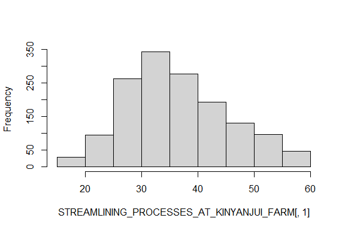

```r
# Identify numeric columns
numeric_columns <- sapply(STREAMLINING_PROCESSES_AT_KINYANJUI_FARM, is.numeric)

# Extract only numeric columns
STREAMLINING_PROCESSES_AT_KINYANJUI_FARM <- STREAMLINING_PROCESSES_AT_KINYANJUI_FARM[, numeric_columns]

STREAMLINING_PROCESSES_AT_KINYANJUI_FARM<- sapply(STREAMLINING_PROCESSES_AT_KINYANJUI_FARM, as.numeric)

# Set up the layout for multiple histograms
par(mfrow = c(1,1))

# Plot histograms for numeric columns


hist(STREAMLINING_PROCESSES_AT_KINYANJUI_FARM[, 1], main = names(STREAMLINING_PROCESSES_AT_KINYANJUI_FARM)[1])
```

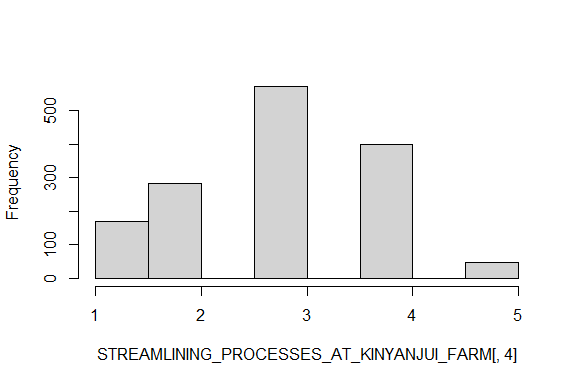

```r
hist(STREAMLINING_PROCESSES_AT_KINYANJUI_FARM[, 4], main = names(STREAMLINING_PROCESSES_AT_KINYANJUI_FARM)[4])
```

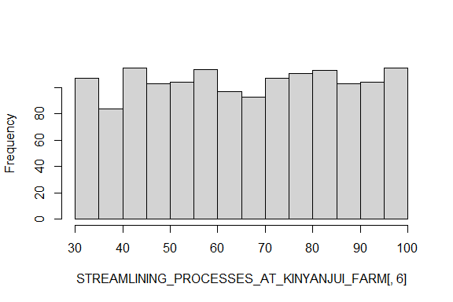

```r
hist(STREAMLINING_PROCESSES_AT_KINYANJUI_FARM[, 6], main = names(STREAMLINING_PROCESSES_AT_KINYANJUI_FARM)[6])
```

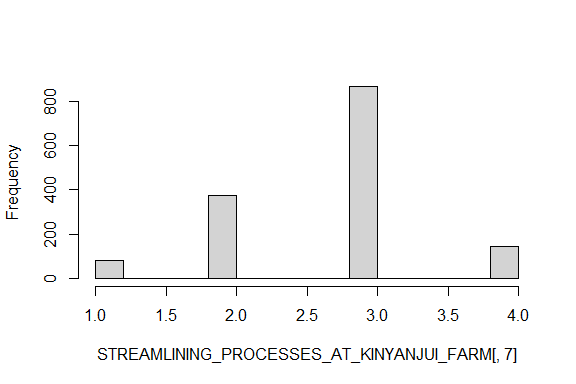

```r
hist(STREAMLINING_PROCESSES_AT_KINYANJUI_FARM[, 7], main = names(STREAMLINING_PROCESSES_AT_KINYANJUI_FARM)[7])
```

```r
hist(STREAMLINING_PROCESSES_AT_KINYANJUI_FARM[, 9], main = names(STREAMLINING_PROCESSES_AT_KINYANJUI_FARM)[9])
```

```r
hist(STREAMLINING_PROCESSES_AT_KINYANJUI_FARM[, 10], main = names(STREAMLINING_PROCESSES_AT_KINYANJUI_FARM)[10])
```

```r
hist(STREAMLINING_PROCESSES_AT_KINYANJUI_FARM[, 11], main = names(STREAMLINING_PROCESSES_AT_KINYANJUI_FARM)[11])
```

```r
hist(STREAMLINING_PROCESSES_AT_KINYANJUI_FARM[, 13], main = names(STREAMLINING_PROCESSES_AT_KINYANJUI_FARM)[13])
```

```r
hist(STREAMLINING_PROCESSES_AT_KINYANJUI_FARM[, 14], main = names(STREAMLINING_PROCESSES_AT_KINYANJUI_FARM)[14])
```

##### Box and Whisker Plots for Each Numeric Attribute

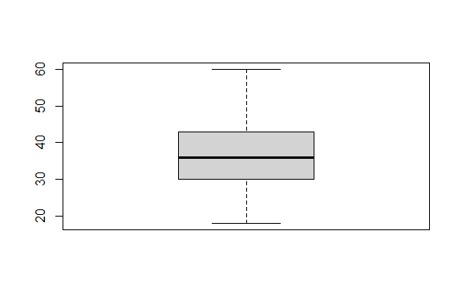

```r
# Set up the layout for multiple histograms
# Plot histograms for numeric columns
for (i in 1:ncol(STREAMLINING_PROCESSES_AT_KINYANJUI_FARM)) {
  jpeg("boxplot.jpg", width = 800, height = 600)
  boxplot(STREAMLINING_PROCESSES_AT_KINYANJUI_FARM[, 1], main = names(STREAMLINING_PROCESSES_AT_KINYANJUI_FARM)[1])
  dev.off()

}

boxplot(STREAMLINING_PROCESSES_AT_KINYANJUI_FARM[, 1], main = names(STREAMLINING_PROCESSES_AT_KINYANJUI_FARM)[1])
```

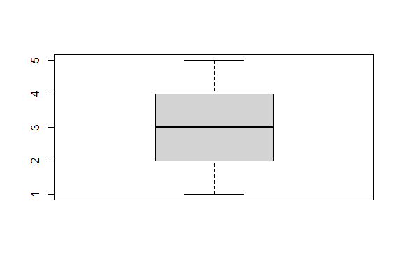

```r
boxplot(STREAMLINING_PROCESSES_AT_KINYANJUI_FARM[, 4], main = names(STREAMLINING_PROCESSES_AT_KINYANJUI_FARM)[4])
```

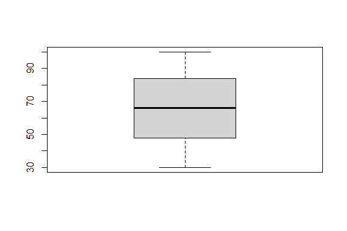

```r
boxplot(STREAMLINING_PROCESSES_AT_KINYANJUI_FARM[, 6], main = names(STREAMLINING_PROCESSES_AT_KINYANJUI_FARM)[6])
```

```r
boxplot(STREAMLINING_PROCESSES_AT_KINYANJUI_FARM[, 7], main = names(STREAMLINING_PROCESSES_AT_KINYANJUI_FARM)[7])
```

```r
boxplot(STREAMLINING_PROCESSES_AT_KINYANJUI_FARM[, 9], main = names(STREAMLINING_PROCESSES_AT_KINYANJUI_FARM)[9])
```

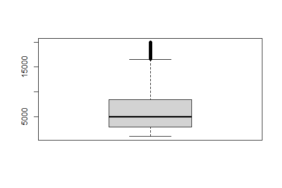

```r
boxplot(STREAMLINING_PROCESSES_AT_KINYANJUI_FARM[, 10], main = names(STREAMLINING_PROCESSES_AT_KINYANJUI_FARM)[10])
```

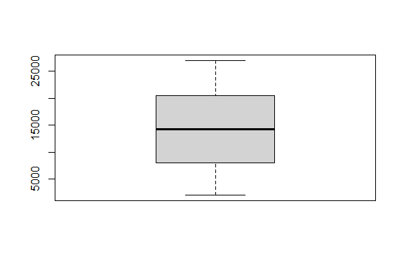

```r
boxplot(STREAMLINING_PROCESSES_AT_KINYANJUI_FARM[, 11], main = names(STREAMLINING_PROCESSES_AT_KINYANJUI_FARM)[11])
```

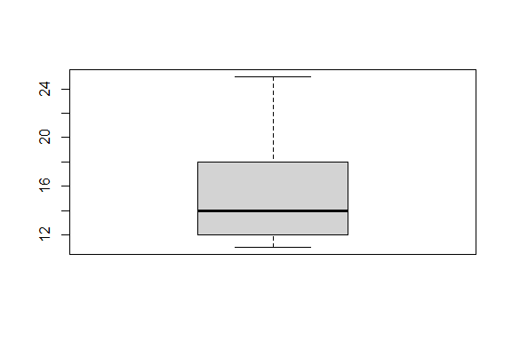

```r
boxplot(STREAMLINING_PROCESSES_AT_KINYANJUI_FARM[, 13], main = names(STREAMLINING_PROCESSES_AT_KINYANJUI_FARM)[13])
```

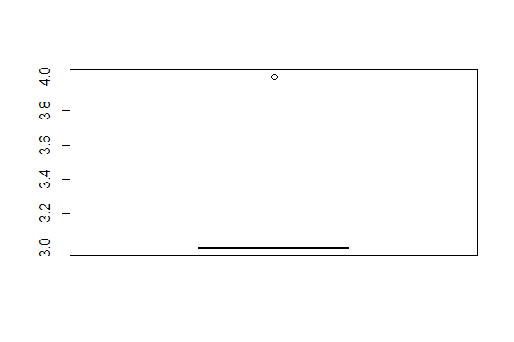

```r
boxplot(STREAMLINING_PROCESSES_AT_KINYANJUI_FARM[, 14], main = names(STREAMLINING_PROCESSES_AT_KINYANJUI_FARM)[14])
```

```r
boxplot(STREAMLINING_PROCESSES_AT_KINYANJUI_FARM[, 15], main = names(STREAMLINING_PROCESSES_AT_KINYANJUI_FARM)[15])
```

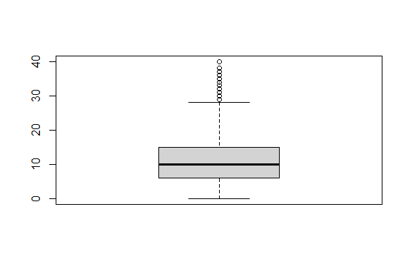

```r
boxplot(STREAMLINING_PROCESSES_AT_KINYANJUI_FARM[, 17], main = names(STREAMLINING_PROCESSES_AT_KINYANJUI_FARM)[17])
```

```r
boxplot(STREAMLINING_PROCESSES_AT_KINYANJUI_FARM[, 19], main = names(STREAMLINING_PROCESSES_AT_KINYANJUI_FARM)[19])
```

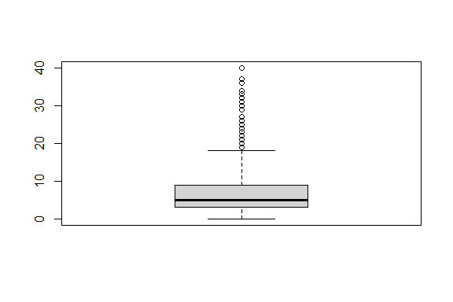

```r
boxplot(STREAMLINING_PROCESSES_AT_KINYANJUI_FARM[, 20], main = names(STREAMLINING_PROCESSES_AT_KINYANJUI_FARM)[20])
```

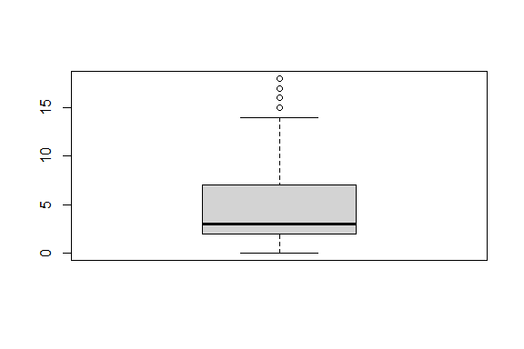

```r
boxplot(STREAMLINING_PROCESSES_AT_KINYANJUI_FARM[, 21], main = names(STREAMLINING_PROCESSES_AT_KINYANJUI_FARM)[21])
```

```r
library(readr)
STREAMLINING_PROCESSES_AT_KINYANJUI_FARM <- read_csv("data/STREAMLINING PROCESSES AT KINYANJUI FARM.csv")
```

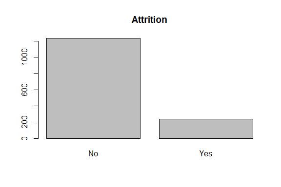

```r
# Drop specified columns
columns_to_drop <- c('EmployeeCount', 'EmployeeNumber', 'Over18', 'StandardHours')
STREAMLINING_PROCESSES_AT_KINYANJUI_FARM <- STREAMLINING_PROCESSES_AT_KINYANJUI_FARM[, !(names(STREAMLINING_PROCESSES_AT_KINYANJUI_FARM) %in% columns_to_drop)]

barplot(table(STREAMLINING_PROCESSES_AT_KINYANJUI_FARM[, 2]), main = names(STREAMLINING_PROCESSES_AT_KINYANJUI_FARM)[2])
```

##### Missingness Map to Identify Missing Data

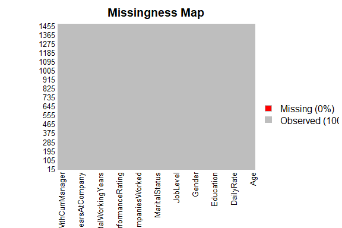

```r
missmap(STREAMLINING_PROCESSES_AT_KINYANJUI_FARM, col = c("red", "grey"), legend = TRUE)
```

#### Multivariate Plots

Multivariate Plots involve visualizations that simultaneously represent and explore the relationships between two or more variables in a dataset. Unlike univariate plots that focus on a single variable, multivariate plots provide insights into the interactions and patterns between multiple variables. Examples of multivariate plots include scatter plots, bubble charts, heatmaps, and 3D plots. These visualizations are essential for identifying correlations, trends, and dependencies between variables, aiding in a more comprehensive understanding of the overall dataset structure. They are particularly useful for uncovering complex relationships and patterns in multidimensional data

##### Correlation Plot

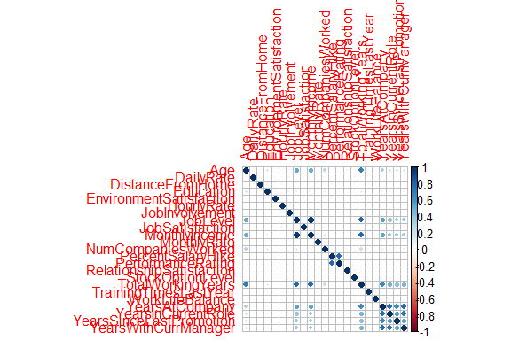

```r
corrplot(cor(STREAMLINING_PROCESSES_AT_KINYANJUI_FARM[, c(1,4, 6, 7, 9, 11, 12, 13, 15 , 17 , 18, 19,  21, 22, 23,24, 25, 26, 27, 28 ,29, 30, 31   )]), method = "circle")
```

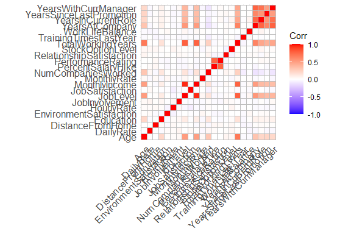

```r
ggcorrplot(cor(STREAMLINING_PROCESSES_AT_KINYANJUI_FARM[, c(1,4, 6, 7, 9, 11, 12, 13, 15 , 17 , 18, 19,  21, 22, 23,24, 25, 26, 27, 28 ,29, 30, 31   )]))
```

##### Scatter Plot

```r
# Select only numeric columns
numeric_columns <- STREAMLINING_PROCESSES_AT_KINYANJUI_FARM[sapply(STREAMLINING_PROCESSES_AT_KINYANJUI_FARM, is.numeric)]

# Create scatterplot matrix
pairs(numeric_columns, col = STREAMLINING_PROCESSES_AT_KINYANJUI_FARM$Age)
```

[figure not shown]

##### Multivariate Box and Whisker Plots by Class

```r
library(readr)
STREAMLINING_PROCESSES_AT_KINYANJUI_FARM <- read_csv("data/STREAMLINING PROCESSES AT KINYANJUI FARM.csv")
```

```r
# Drop specified columns
columns_to_drop <- c('EmployeeCount', 'EmployeeNumber', 'Over18', 'StandardHours')
STREAMLINING_PROCESSES_AT_KINYANJUI_FARM <- STREAMLINING_PROCESSES_AT_KINYANJUI_FARM[, !(names(STREAMLINING_PROCESSES_AT_KINYANJUI_FARM) %in% columns_to_drop)]
featurePlot(x = STREAMLINING_PROCESSES_AT_KINYANJUI_FARM[, c(1,4, 6, 7, 9, 11, 12, 13, 15 , 17 , 18, 19,  21, 22, 23,24, 25, 26, 27, 28 ,29, 30, 31   )], y = STREAMLINING_PROCESSES_AT_KINYANJUI_FARM[, 2],
            plot = "box")
```

# Preprocessing and Data Transformation

Preprocessing and Data Transformation” refer to the steps taken to prepare raw data for analysis. This involves cleaning, organizing, and modifying the data to improve its quality and make it suitable for modeling. Common preprocessing tasks include handling `missing values`, `removing outliers`, `scaling or normalizing numerical features`, `encoding categorical variables`, and `splitting the data into training and testing sets`. Data transformation may also involve creating new features or aggregating existing ones. These processes are crucial for enhancing the accuracy and effectiveness of machine learning models

```r
## Confirm the "missingness" in the Initial Dataset ----

# Are there missing values in the dataset?
any_na(STREAMLINING_PROCESSES_AT_KINYANJUI_FARM)
```

```
## [1] FALSE
```

```r
# How many?
n_miss(STREAMLINING_PROCESSES_AT_KINYANJUI_FARM)
```

```
## [1] 0
```

```r
# What is the percentage of missing data in the entire dataset?
prop_miss(STREAMLINING_PROCESSES_AT_KINYANJUI_FARM)
```

```
## [1] 0
```

```r
# How many missing values does each variable have?
STREAMLINING_PROCESSES_AT_KINYANJUI_FARM %>% is.na() %>% colSums()
```

```
##                      Age                Attrition           BusinessTravel
##                        0                        0                        0
##                DailyRate               Department         DistanceFromHome
##                        0                        0                        0
##                Education           EducationField  EnvironmentSatisfaction
##                        0                        0                        0
##                   Gender               HourlyRate           JobInvolvement
##                        0                        0                        0
##                 JobLevel                  JobRole          JobSatisfaction
##                        0                        0                        0
##            MaritalStatus            MonthlyIncome              MonthlyRate
##                        0                        0                        0
##       NumCompaniesWorked                 OverTime        PercentSalaryHike
##                        0                        0                        0
##        PerformanceRating RelationshipSatisfaction         StockOptionLevel
##                        0                        0                        0
##        TotalWorkingYears    TrainingTimesLastYear          WorkLifeBalance
##                        0                        0                        0
##           YearsAtCompany       YearsInCurrentRole  YearsSinceLastPromotion
##                        0                        0                        0
##     YearsWithCurrManager
##                        0
```

```r
# What is the number and percentage of missing values grouped by
# each variable?
miss_var_summary(STREAMLINING_PROCESSES_AT_KINYANJUI_FARM)
```

```
## # A tibble: 31 × 3
##    variable                n_miss pct_miss
##    <chr>                    <int>    <dbl>
##  1 Age                          0        0
##  2 Attrition                    0        0
##  3 BusinessTravel               0        0
##  4 DailyRate                    0        0
##  5 Department                   0        0
##  6 DistanceFromHome             0        0
##  7 Education                    0        0
##  8 EducationField               0        0
##  9 EnvironmentSatisfaction      0        0
## 10 Gender                       0        0
## # ℹ 21 more rows
```

```r
# What is the number and percentage of missing values grouped by
# each observation?
miss_case_summary(STREAMLINING_PROCESSES_AT_KINYANJUI_FARM)
```

```
## # A tibble: 1,470 × 3
##     case n_miss pct_miss
##    <int>  <int>    <dbl>
##  1     1      0        0
##  2     2      0        0
##  3     3      0        0
##  4     4      0        0
##  5     5      0        0
##  6     6      0        0
##  7     7      0        0
##  8     8      0        0
##  9     9      0        0
## 10    10      0        0
## # ℹ 1,460 more rows
```

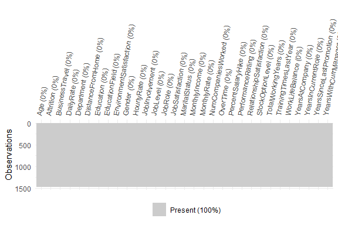

```r
# Which variables contain the most missing values?
#gg_miss_var(STREAMLINING_PROCESSES_AT_KINYANJUI_FARM)

# Where are missing values located (the shaded regions in the plot)?
vis_miss(STREAMLINING_PROCESSES_AT_KINYANJUI_FARM) + theme(axis.text.x = element_text(angle = 80))
```

```r
# Which combinations of variables are missing together?
#gg_miss_upset(STREAMLINING_PROCESSES_AT_KINYANJUI_FARM)
```

#### Heatmap of “missingness” broken down by “Age”

```r
# First, confirm that the "AgeDecade" variable is a categorical variable
is.factor(STREAMLINING_PROCESSES_AT_KINYANJUI_FARM$Age)
```

```
## [1] FALSE
```

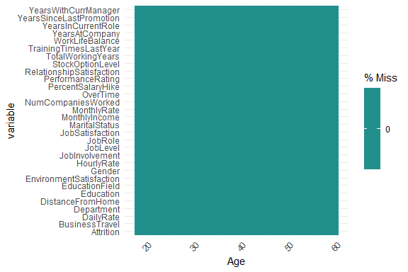

```r
# Second, create the visualization
gg_miss_fct(STREAMLINING_PROCESSES_AT_KINYANJUI_FARM, fct = Age)
```

```r
# We can also create a heatmap of "missingness" broken down by "Depressed"
# First, confirm that the "Depressed" variable is a categorical variable
is.factor(STREAMLINING_PROCESSES_AT_KINYANJUI_FARM$Attrition)
```

```
## [1] FALSE
```

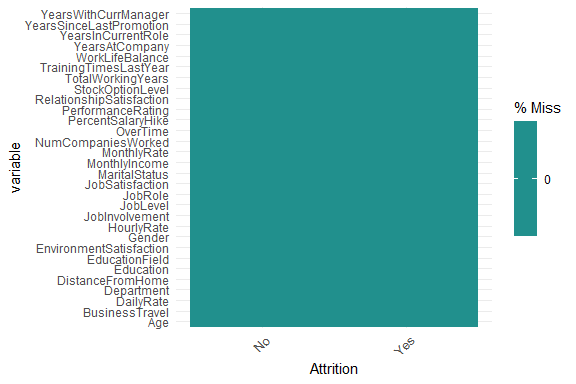

```r
# Second, create the visualization
gg_miss_fct(STREAMLINING_PROCESSES_AT_KINYANJUI_FARM, fct = Attrition)
```

## Data Transformation

#### Scale Data Transform

```r
# Scale Data Transform
# BEFORE
# Identify numeric columns

library(readr)
STREAMLINING_PROCESSES_AT_KINYANJUI_FARM <- read_csv("data/STREAMLINING PROCESSES AT KINYANJUI FARM.csv")
```

```r
# Drop specified columns
columns_to_drop <- c('EmployeeCount', 'EmployeeNumber', 'Over18', 'StandardHours')
STREAMLINING_PROCESSES_AT_KINYANJUI_FARM <- STREAMLINING_PROCESSES_AT_KINYANJUI_FARM[, !(names(STREAMLINING_PROCESSES_AT_KINYANJUI_FARM) %in% columns_to_drop)]
numeric_columns <- sapply(STREAMLINING_PROCESSES_AT_KINYANJUI_FARM, is.numeric)

# Extract only numeric columns
STREAMLINING_PROCESSES_AT_KINYANJUI_FARM <- STREAMLINING_PROCESSES_AT_KINYANJUI_FARM[, numeric_columns]

STREAMLINING_PROCESSES_AT_KINYANJUI_FARM<- sapply(STREAMLINING_PROCESSES_AT_KINYANJUI_FARM, as.numeric)

# Set up the layout for multiple histograms
par(mfrow = c(1, 1))

summary(STREAMLINING_PROCESSES_AT_KINYANJUI_FARM)
```

```
##       Age          DailyRate      DistanceFromHome   Education
##  Min.   :18.00   Min.   : 102.0   Min.   : 1.000   Min.   :1.000
##  1st Qu.:30.00   1st Qu.: 465.0   1st Qu.: 2.000   1st Qu.:2.000
##  Median :36.00   Median : 802.0   Median : 7.000   Median :3.000
##  Mean   :36.92   Mean   : 802.5   Mean   : 9.193   Mean   :2.913
##  3rd Qu.:43.00   3rd Qu.:1157.0   3rd Qu.:14.000   3rd Qu.:4.000
##  Max.   :60.00   Max.   :1499.0   Max.   :29.000   Max.   :5.000
##  EnvironmentSatisfaction   HourlyRate     JobInvolvement    JobLevel
##  Min.   :1.000           Min.   : 30.00   Min.   :1.00   Min.   :1.000
##  1st Qu.:2.000           1st Qu.: 48.00   1st Qu.:2.00   1st Qu.:1.000
##  Median :3.000           Median : 66.00   Median :3.00   Median :2.000
##  Mean   :2.722           Mean   : 65.89   Mean   :2.73   Mean   :2.064
##  3rd Qu.:4.000           3rd Qu.: 83.75   3rd Qu.:3.00   3rd Qu.:3.000
##  Max.   :4.000           Max.   :100.00   Max.   :4.00   Max.   :5.000
##  JobSatisfaction MonthlyIncome    MonthlyRate    NumCompaniesWorked
##  Min.   :1.000   Min.   : 1009   Min.   : 2094   Min.   :0.000
##  1st Qu.:2.000   1st Qu.: 2911   1st Qu.: 8047   1st Qu.:1.000
##  Median :3.000   Median : 4919   Median :14236   Median :2.000
##  Mean   :2.729   Mean   : 6503   Mean   :14313   Mean   :2.693
##  3rd Qu.:4.000   3rd Qu.: 8379   3rd Qu.:20462   3rd Qu.:4.000
##  Max.   :4.000   Max.   :19999   Max.   :26999   Max.   :9.000
##  PercentSalaryHike PerformanceRating RelationshipSatisfaction StockOptionLevel
##  Min.   :11.00     Min.   :3.000     Min.   :1.000            Min.   :0.0000
##  1st Qu.:12.00     1st Qu.:3.000     1st Qu.:2.000            1st Qu.:0.0000
##  Median :14.00     Median :3.000     Median :3.000            Median :1.0000
##  Mean   :15.21     Mean   :3.154     Mean   :2.712            Mean   :0.7939
##  3rd Qu.:18.00     3rd Qu.:3.000     3rd Qu.:4.000            3rd Qu.:1.0000
##  Max.   :25.00     Max.   :4.000     Max.   :4.000            Max.   :3.0000
##  TotalWorkingYears TrainingTimesLastYear WorkLifeBalance YearsAtCompany
##  Min.   : 0.00     Min.   :0.000         Min.   :1.000   Min.   : 0.000
##  1st Qu.: 6.00     1st Qu.:2.000         1st Qu.:2.000   1st Qu.: 3.000
##  Median :10.00     Median :3.000         Median :3.000   Median : 5.000
##  Mean   :11.28     Mean   :2.799         Mean   :2.761   Mean   : 7.008
##  3rd Qu.:15.00     3rd Qu.:3.000         3rd Qu.:3.000   3rd Qu.: 9.000
##  Max.   :40.00     Max.   :6.000         Max.   :4.000   Max.   :40.000
##  YearsInCurrentRole YearsSinceLastPromotion YearsWithCurrManager
##  Min.   : 0.000     Min.   : 0.000          Min.   : 0.000
##  1st Qu.: 2.000     1st Qu.: 0.000          1st Qu.: 2.000
##  Median : 3.000     Median : 1.000          Median : 3.000
##  Mean   : 4.229     Mean   : 2.188          Mean   : 4.123
##  3rd Qu.: 7.000     3rd Qu.: 3.000          3rd Qu.: 7.000
##  Max.   :18.000     Max.   :15.000          Max.   :17.000
```

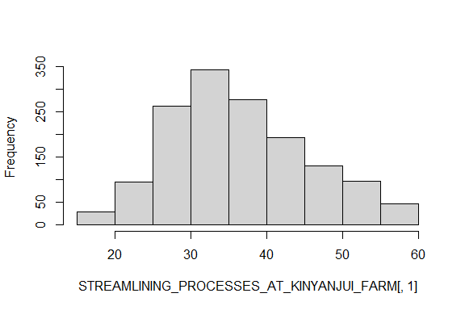

```r
hist(STREAMLINING_PROCESSES_AT_KINYANJUI_FARM[, 1], main = names(STREAMLINING_PROCESSES_AT_KINYANJUI_FARM)[1])
```

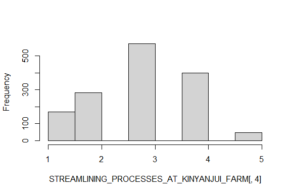

```r
hist(STREAMLINING_PROCESSES_AT_KINYANJUI_FARM[, 4], main = names(STREAMLINING_PROCESSES_AT_KINYANJUI_FARM)[4])
```

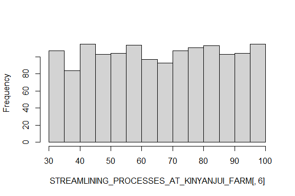

```r
hist(STREAMLINING_PROCESSES_AT_KINYANJUI_FARM[, 6], main = names(STREAMLINING_PROCESSES_AT_KINYANJUI_FARM)[6])
```

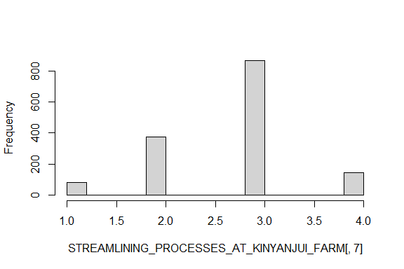

```r
hist(STREAMLINING_PROCESSES_AT_KINYANJUI_FARM[, 7], main = names(STREAMLINING_PROCESSES_AT_KINYANJUI_FARM)[7])
```

```r
hist(STREAMLINING_PROCESSES_AT_KINYANJUI_FARM[, 9], main = names(STREAMLINING_PROCESSES_AT_KINYANJUI_FARM)[9])
```

```r
hist(STREAMLINING_PROCESSES_AT_KINYANJUI_FARM[, 10], main = names(STREAMLINING_PROCESSES_AT_KINYANJUI_FARM)[10])
```

```r
hist(STREAMLINING_PROCESSES_AT_KINYANJUI_FARM[, 11], main = names(STREAMLINING_PROCESSES_AT_KINYANJUI_FARM)[11])
```

```r
hist(STREAMLINING_PROCESSES_AT_KINYANJUI_FARM[, 13], main = names(STREAMLINING_PROCESSES_AT_KINYANJUI_FARM)[13])
```

```r
hist(STREAMLINING_PROCESSES_AT_KINYANJUI_FARM[, 14], main = names(STREAMLINING_PROCESSES_AT_KINYANJUI_FARM)[14])
```

```r
model_of_the_transform <- preProcess(STREAMLINING_PROCESSES_AT_KINYANJUI_FARM, method = c("scale"))
print(model_of_the_transform)
```

```
## Created from 1470 samples and 23 variables
##
## Pre-processing:
##   - ignored (0)
##   - scaled (23)
```

```r
streamling_processes_scale_transform <- predict(model_of_the_transform,
                                          STREAMLINING_PROCESSES_AT_KINYANJUI_FARM)

#After
summary(streamling_processes_scale_transform)
```

```
##       Age          DailyRate      DistanceFromHome   Education
##  Min.   :1.970   Min.   :0.2528   Min.   :0.1234   Min.   :0.9764
##  1st Qu.:3.284   1st Qu.:1.1524   1st Qu.:0.2467   1st Qu.:1.9528
##  Median :3.941   Median :1.9876   Median :0.8635   Median :2.9292
##  Mean   :4.042   Mean   :1.9888   Mean   :1.1339   Mean   :2.8442
##  3rd Qu.:4.707   3rd Qu.:2.8673   3rd Qu.:1.7269   3rd Qu.:3.9056
##  Max.   :6.568   Max.   :3.7149   Max.   :3.5772   Max.   :4.8820
##  EnvironmentSatisfaction   HourlyRate    JobInvolvement     JobLevel
##  Min.   :0.9148          Min.   :1.476   Min.   :1.405   Min.   :0.9034
##  1st Qu.:1.8297          1st Qu.:2.361   1st Qu.:2.811   1st Qu.:0.9034
##  Median :2.7445          Median :3.247   Median :4.216   Median :1.8068
##  Mean   :2.4900          Mean   :3.241   Mean   :3.837   Mean   :1.8646
##  3rd Qu.:3.6594          3rd Qu.:4.120   3rd Qu.:4.216   3rd Qu.:2.7102
##  Max.   :3.6594          Max.   :4.919   Max.   :5.621   Max.   :4.5170
##  JobSatisfaction  MonthlyIncome     MonthlyRate     NumCompaniesWorked
##  Min.   :0.9067   Min.   :0.2143   Min.   :0.2942   Min.   :0.0000
##  1st Qu.:1.8135   1st Qu.:0.6183   1st Qu.:1.1305   1st Qu.:0.4003
##  Median :2.7202   Median :1.0448   Median :2.0000   Median :0.8006
##  Mean   :2.4741   Mean   :1.3813   Mean   :2.0109   Mean   :1.0781
##  3rd Qu.:3.6270   3rd Qu.:1.7798   3rd Qu.:2.8747   3rd Qu.:1.6013
##  Max.   :3.6270   Max.   :4.2479   Max.   :3.7932   Max.   :3.6029
##  PercentSalaryHike PerformanceRating RelationshipSatisfaction StockOptionLevel
##  Min.   :3.006     Min.   : 8.314    Min.   :0.9249           Min.   :0.0000
##  1st Qu.:3.279     1st Qu.: 8.314    1st Qu.:1.8498           1st Qu.:0.0000
##  Median :3.825     Median : 8.314    Median :2.7747           Median :1.1736
##  Mean   :4.156     Mean   : 8.740    Mean   :2.5085           Mean   :0.9317
##  3rd Qu.:4.918     3rd Qu.: 8.314    3rd Qu.:3.6996           3rd Qu.:1.1736
##  Max.   :6.831     Max.   :11.086    Max.   :3.6996           Max.   :3.5208
##  TotalWorkingYears TrainingTimesLastYear WorkLifeBalance YearsAtCompany
##  Min.   :0.0000    Min.   :0.000         Min.   :1.415   Min.   :0.0000
##  1st Qu.:0.7711    1st Qu.:1.551         1st Qu.:2.831   1st Qu.:0.4897
##  Median :1.2852    Median :2.327         Median :4.246   Median :0.8161
##  Mean   :1.4497    Mean   :2.171         Mean   :3.908   Mean   :1.1439
##  3rd Qu.:1.9278    3rd Qu.:2.327         3rd Qu.:4.246   3rd Qu.:1.4690
##  Max.   :5.1409    Max.   :4.654         Max.   :5.662   Max.   :6.5290
##  YearsInCurrentRole YearsSinceLastPromotion YearsWithCurrManager
##  Min.   :0.000      Min.   :0.0000          Min.   :0.0000
##  1st Qu.:0.552      1st Qu.:0.0000          1st Qu.:0.5605
##  Median :0.828      Median :0.3103          Median :0.8408
##  Mean   :1.167      Mean   :0.6789          Mean   :1.1555
##  3rd Qu.:1.932      3rd Qu.:0.9310          3rd Qu.:1.9618
##  Max.   :4.968      Max.   :4.6549          Max.   :4.7644
```

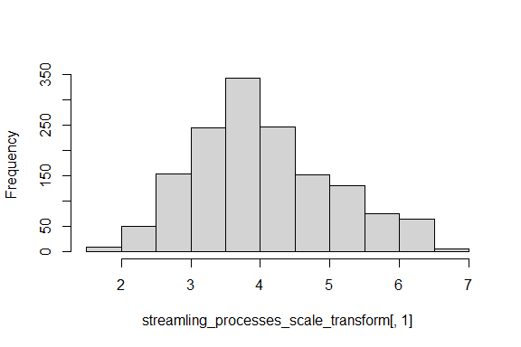

```r
hist(streamling_processes_scale_transform[, 1], main = names(streamling_processes_scale_transform)[1])
```

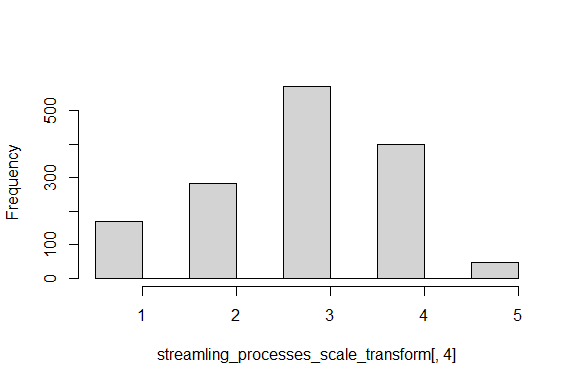

```r
hist(streamling_processes_scale_transform[, 4], main = names(streamling_processes_scale_transform)[4])
```

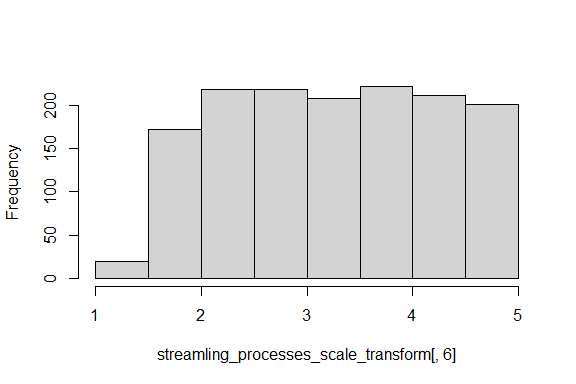

```r
hist(streamling_processes_scale_transform[, 6], main = names(streamling_processes_scale_transform)[6])
```

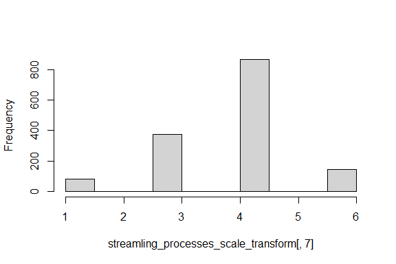

```r
hist(streamling_processes_scale_transform[, 7], main = names(streamling_processes_scale_transform)[7])
```

```r
hist(STREAMLINING_PROCESSES_AT_KINYANJUI_FARM[, 9], main = names(STREAMLINING_PROCESSES_AT_KINYANJUI_FARM)[9])
```

```r
hist(STREAMLINING_PROCESSES_AT_KINYANJUI_FARM[, 10], main = names(STREAMLINING_PROCESSES_AT_KINYANJUI_FARM)[10])
```

```r
hist(STREAMLINING_PROCESSES_AT_KINYANJUI_FARM[, 11], main = names(STREAMLINING_PROCESSES_AT_KINYANJUI_FARM)[11])
```

```r
hist(STREAMLINING_PROCESSES_AT_KINYANJUI_FARM[, 13], main = names(STREAMLINING_PROCESSES_AT_KINYANJUI_FARM)[13])
```

```r
hist(STREAMLINING_PROCESSES_AT_KINYANJUI_FARM[, 14], main = names(STREAMLINING_PROCESSES_AT_KINYANJUI_FARM)[14])
```